# R Notebook

# **PROJECT 4: Pima Diabetes - Detecting Diabetes from Imperfect Medical Data**

Project Goal : As data analysts in the healthcare sector, your team must build a model to predict the likelihood of diabetes in female patients of Pima Indian heritage. The primary challenge of this dataset is the presence of “impossible” data (zero values for biological measurements) that mask missing values. Your success will depend on your ability to identify and correct these anomalies before modeling.

## **Step 1: Data Cleaning and Preparation**

First, we import the data. Then we look at the beginning of the table to familiarize ourselves with it. And we create a summary to get an overview of the range of numerical values.

|  | Pregnancies | Glucose | BloodPressure | SkinThickness | Insulin | BMI | DiabetesPedigreeFunction | Age | Outcome |
| --- | --- | --- | --- | --- | --- | --- | --- | --- | --- |
| 1 | 6 | 148 | 72 | 35 | 0 | 33.6 | 0.627 | 50 | 1 |
| 2 | 1 | 85 | 66 | 29 | 0 | 26.6 | 0.351 | 31 | 0 |
| 3 | 8 | 183 | 64 | 0 | 0 | 23.3 | 0.672 | 32 | 1 |
| 4 | 1 | 89 | 66 | 23 | 94 | 28.1 | 0.167 | 21 | 0 |
| 5 | 0 | 137 | 40 | 35 | 168 | 43.1 | 2.288 | 33 | 1 |
| 6 | 5 | 116 | 74 | 0 | 0 | 25.6 | 0.201 | 30 | 0 |

```
  Pregnancies        Glucose      BloodPressure    SkinThickness      Insulin
 Min.   : 0.000   Min.   :  0.0   Min.   :  0.00   Min.   : 0.00   Min.   :  0.0
 1st Qu.: 1.000   1st Qu.: 99.0   1st Qu.: 62.00   1st Qu.: 0.00   1st Qu.:  0.0
 Median : 3.000   Median :117.0   Median : 72.00   Median :23.00   Median : 30.5
 Mean   : 3.845   Mean   :120.9   Mean   : 69.11   Mean   :20.54   Mean   : 79.8
 3rd Qu.: 6.000   3rd Qu.:140.2   3rd Qu.: 80.00   3rd Qu.:32.00   3rd Qu.:127.2
 Max.   :17.000   Max.   :199.0   Max.   :122.00   Max.   :99.00   Max.   :846.0
      BMI        DiabetesPedigreeFunction      Age           Outcome
 Min.   : 0.00   Min.   :0.0780           Min.   :21.00   Min.   :0.000
 1st Qu.:27.30   1st Qu.:0.2437           1st Qu.:24.00   1st Qu.:0.000
 Median :32.00   Median :0.3725           Median :29.00   Median :0.000
 Mean   :31.99   Mean   :0.4719           Mean   :33.24   Mean   :0.349
 3rd Qu.:36.60   3rd Qu.:0.6262           3rd Qu.:41.00   3rd Qu.:1.000
 Max.   :67.10   Max.   :2.4200           Max.   :81.00   Max.   :1.000
```

We observe that certain values are 0. However, this does not always make sense in a medical context. We deduce that these values are missing. We will replace them with ‘NA’.

|  | Pregnancies | Glucose | BloodPressure | SkinThickness | Insulin | BMI | DiabetesPedigreeFunction | Age | Outcome |
| --- | --- | --- | --- | --- | --- | --- | --- | --- | --- |
| 1 | 6 | 148 | 72 | 35 | NA | 33.6 | 0.627 | 50 | 1 |
| 2 | 1 | 85 | 66 | 29 | NA | 26.6 | 0.351 | 31 | 0 |
| 3 | 8 | 183 | 64 | NA | NA | 23.3 | 0.672 | 32 | 1 |
| 4 | 1 | 89 | 66 | 23 | 94 | 28.1 | 0.167 | 21 | 0 |
| 5 | 0 | 137 | 40 | 35 | 168 | 43.1 | 2.288 | 33 | 1 |
| 6 | 5 | 116 | 74 | NA | NA | 25.6 | 0.201 | 30 | 0 |

The ‘NA’ value count:

```
             Pregnancies                  Glucose            BloodPressure
                       0                        5                       35
           SkinThickness                  Insulin                      BMI
                     227                      374                       11
DiabetesPedigreeFunction                      Age                  Outcome
                       0                        0                        0
```

In order to analyze our dataset, we need to fill in the ‘NA’ values. We choose to replace them with the median of their respective column.

|  | Pregnancies | Glucose | BloodPressure | SkinThickness | Insulin | BMI | DiabetesPedigreeFunction | Age | Outcome |
| --- | --- | --- | --- | --- | --- | --- | --- | --- | --- |
| 1 | 6 | 148 | 72 | 35 | 125 | 33.6 | 0.627 | 50 | 1 |
| 2 | 1 | 85 | 66 | 29 | 125 | 26.6 | 0.351 | 31 | 0 |
| 3 | 8 | 183 | 64 | 29 | 125 | 23.3 | 0.672 | 32 | 1 |
| 4 | 1 | 89 | 66 | 23 | 94 | 28.1 | 0.167 | 21 | 0 |
| 5 | 0 | 137 | 40 | 35 | 168 | 43.1 | 2.288 | 33 | 1 |
| 6 | 5 | 116 | 74 | 29 | 125 | 25.6 | 0.201 | 30 | 0 |

All ‘NA’ values have been replaced & no more 0 remains:

```
             Pregnancies                  Glucose            BloodPressure
                       0                        0                        0
           SkinThickness                  Insulin                      BMI
                       0                        0                        0
DiabetesPedigreeFunction                      Age                  Outcome
                       0                        0                        0

      Glucose BloodPressure SkinThickness       Insulin           BMI
            0             0             0             0             0
```

## **Step 2: Feature Transformation and Engineering**

Before starting the analysis, we need to perform some transformations on our data.

### **Part 1: Creating BMI Categories**

Create a new categorical variable BMICategory from BMI using the World Health Organization’s standard thresholds.

| BMICategory | n |
| --- | --- |
| Underweight | 4 |
| Normal weight | 102 |
| Overweight | 179 |
| Obese | 483 |

### **Part 2: Creating Blood Pressure Categories**

Similarly, we create a BPCategory variable from BloodPressure

| BPCategory | n |
| --- | --- |
| Low | 86 |
| Normal | 477 |
| Elevated | 145 |
| High | 60 |

### **Part 3: Target Transformation**

Now, we ensure the target variable Outcome is a factor with clear labels (e.g., “Diabetic”, “Not Diabetic”) for interpretability.

| OutcomeLabel | n |
| --- | --- |
| Not Diabetic | 500 |
| Diabetic | 268 |

### **Part 4: Standardizing Variables**

Center and scale all numeric columns so their mean becomes 0 and their standard deviation becomes 1.

|  | Pregnancies | Glucose | BloodPressure | SkinThickness | Insulin | BMI | DiabetesPedigreeFunction | Age | Outcome | BMICategory | BPCategory | OutcomeLabel |
| --- | --- | --- | --- | --- | --- | --- | --- | --- | --- | --- | --- | --- |
| 1 | 0.6395305 | 0.8654807 | -0.0319691 | 0.67020577 | -0.1814230 | 0.1665109 | 0.4681869 | 1.42506672 | 1 | Obese | Normal | Diabetic |
| 2 | -0.8443348 | -1.2042810 | -0.5279745 | -0.01229328 | -0.1814230 | -0.8516448 | -0.3648230 | -0.19054773 | 0 | Overweight | Normal | Not Diabetic |
| 3 | 1.2330766 | 2.0153484 | -0.6933097 | -0.01229328 | -0.1814230 | -1.3316324 | 0.6040037 | -0.10551539 | 1 | Normal weight | Normal | Diabetic |
| 4 | -0.8443348 | -1.0728676 | -0.5279745 | -0.69479233 | -0.5402897 | -0.6334686 | -0.9201630 | -1.04087112 | 0 | Overweight | Normal | Not Diabetic |
| 5 | -1.1411079 | 0.5040938 | -2.6773314 | 0.67020577 | 0.3163598 | 1.5482935 | 5.4813370 | -0.02048305 | 1 | Obese | Low | Diabetic |
| 6 | 0.3427574 | -0.1858268 | 0.1333660 | -0.01229328 | -0.1814230 | -0.9970956 | -0.8175458 | -0.27558007 | 0 | Overweight | Normal | Not Diabetic |

## **Step 3: Visualization and Exploration (with ggplot2)**

Now that our data has been cleaned, we can begin the analysis. Let’s first look at the impact of cleaning on glucose value distributions.

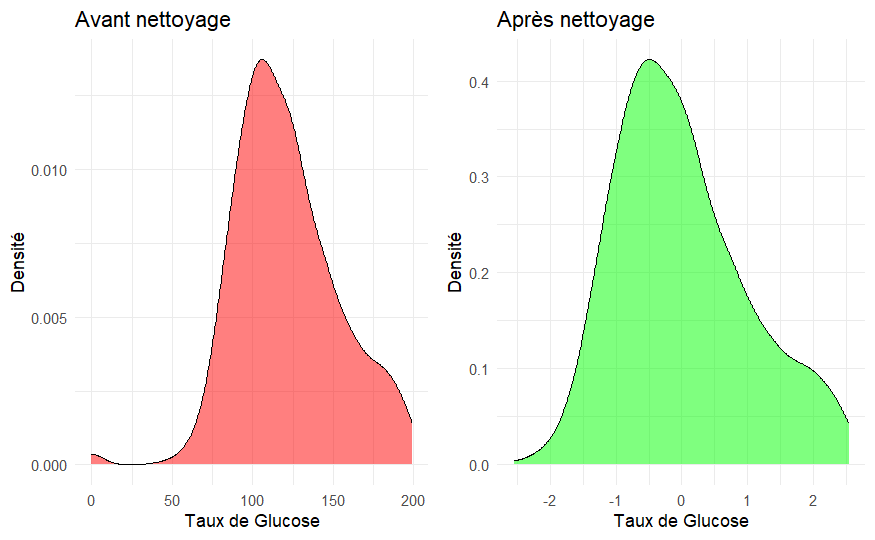

### **Part 1: Comparing Distributions**

Now let’s look at the distribution of BMI and age according to whether or not the patient has diabetes.

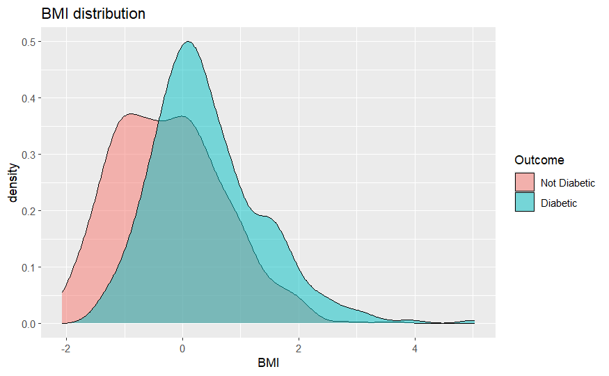

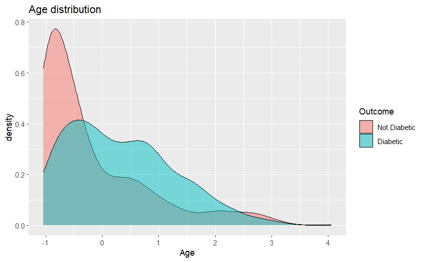

It can be observed that diabetes is associated with a higher BMI than among non-diabetic patients.

### **Part 2: Correlation Between Predictors**

Here we calculate the correlation matrix between all numerical variables to identify those that are correlated.

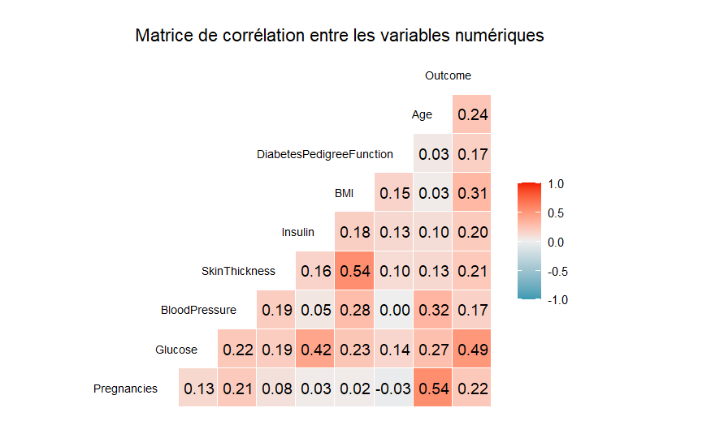

There is a strong correlation between diabetes rates and glucose levels. As expected.

### **Part 3: Analyzing Pedigree**

On the contrary, if we visualize two variables that have a low correlation score, we cannot distinguish anything in particular.

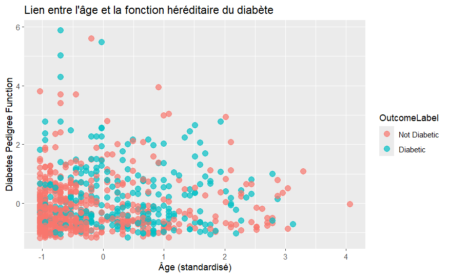

### **Part 4: Visualisations of our choice**

As announced, glucose distribution is higher in diabetic patients.

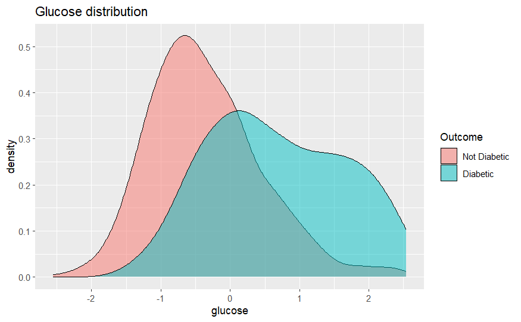

Another thing that was to be expected: blood pressure increases with age.

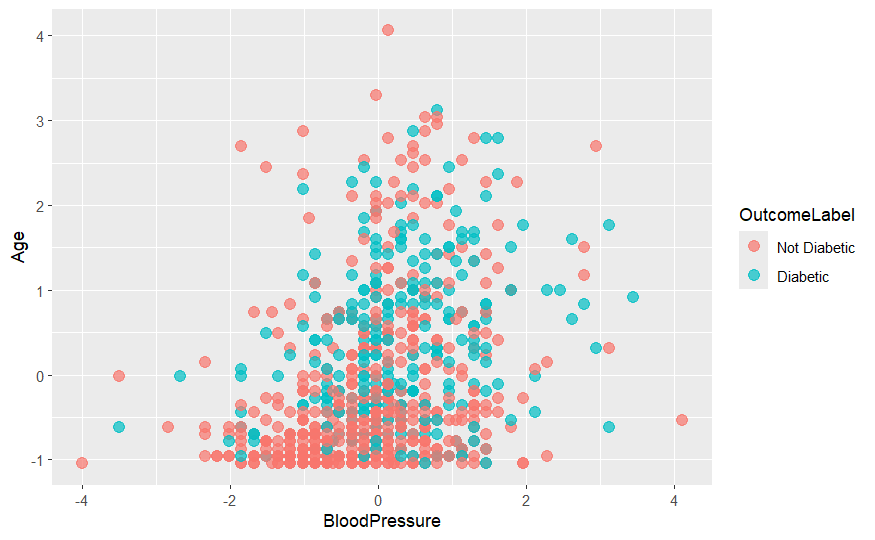

## **Step 4: Modeling and Prediction (Data Science)**

### **Part 1: Logistic Regression Model**

We train a logistic regression model (A model that predicts the probability of a binary event occurring) on the standardized data. The training data volume represents 80% of the total data. The model is tested on the remaining 20%.

```
         Actual
Predicted  0  1
        0 89 23
        1 13 29

[1] 0.7662338
```

This model allow you to see the effect (positive or negative) of each variable.

```
Call:
glm(formula = Outcome ~ Glucose + BMI + Age + DiabetesPedigreeFunction +
    Pregnancies + BloodPressure + SkinThickness, family = binomial,
    data = train_data)

Coefficients:
                          Estimate Std. Error z value Pr(>|z|)
(Intercept)              -0.859299   0.108381  -7.929 2.22e-15 ***
Glucose                   1.143281   0.125294   9.125  < 2e-16 ***
BMI                       0.636216   0.136339   4.666 3.07e-06 ***
Age                       0.162128   0.124839   1.299  0.19405
DiabetesPedigreeFunction  0.230738   0.106118   2.174  0.02968 *
Pregnancies               0.398935   0.122054   3.269  0.00108 **
BloodPressure            -0.137484   0.116312  -1.182  0.23719
SkinThickness             0.003367   0.126720   0.027  0.97880
---
Signif. codes:  0 ‘***’ 0.001 ‘**’ 0.01 ‘*’ 0.05 ‘.’ 0.1 ‘ ’ 1

(Dispersion parameter for binomial family taken to be 1)

    Null deviance: 796.42  on 613  degrees of freedom
Residual deviance: 570.81  on 606  degrees of freedom
AIC: 586.81

Number of Fisher Scoring iterations: 5
```

### **Part 2: k-Nearest Neighbors (KNN) Model**

A KNN model classifies a patient based on the majority class of their closest “neighbors” in the feature space. At first, we take k=3.

```
         Actual
Predicted  0  1
        0 91 20
        1 11 32

[1] 0.7987013
```

### **Part 3: Cross-Validation**

Cross-validation involves dividing your dataset into several subsets to train your model on one part and test it on the others, in order to evaluate its performance more reliably and avoid overfitting.

This second version of the LRM offers greater precision than the previous one.

|  | parameter | Accuracy | Kappa | AccuracySD | KappaSD |
| --- | --- | --- | --- | --- | --- |
| 1 | none | 0.7694805 | 0.4654565 | 0.05201072 | 0.1235555 |

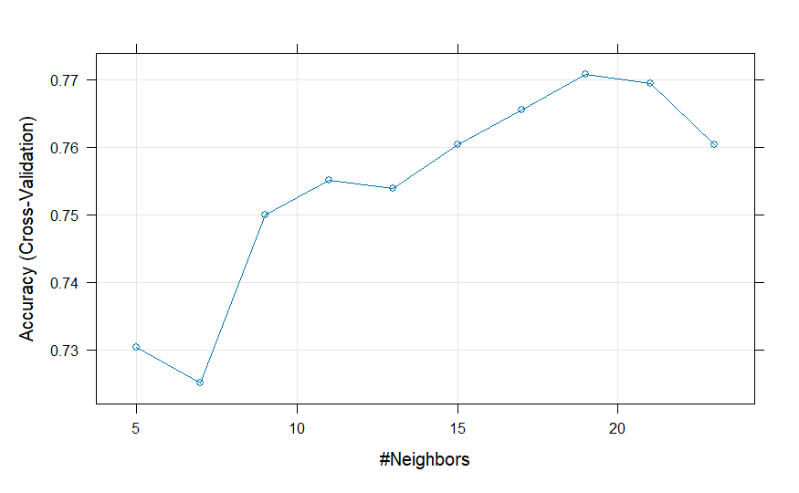

### **Part 4: Analyzing the Impact of Cleaning**

The model trained on uncleaned data achieves higher accuracy solely because it exploits unrealistic zero values as artificial indicators of diagnosis. After cleaning, accuracy decreases slightly, but performance becomes more reliable and more representative of real-world usage.

```
         Actual
Predicted  0  1
        0 90 22
        1 12 30

[1] 0.7792208
```